# iterated_learning

Madeline Meyers, Dan Yurovsky

7/19/2018

## Read in Data (saved as .csv taken from Google Sheet, includes only full chains)

## Format Data for Display & Grid Analysis

```r
input_labs <- c("input_0_0", "input_0_1", "input_0_2", "input_0_3", "input_0_4", "input_0_5", "input_0_6", "input_0_7", "input_1_0", "input_1_1", "input_1_2", "input_1_3", "input_1_4", "input_1_5", "input_1_6", "input_1_7", "input_2_0", "input_2_1", "input_2_2", "input_2_3", "input_2_4", "input_2_5", "input_2_6", "input_2_7", "input_3_0", "input_3_1", "input_3_2", "input_3_3", "input_3_4", "input_3_5", "input_3_6", "input_3_7", "input_4_0", "input_4_1", "input_4_2", "input_4_3", "input_4_4", "input_4_5", "input_4_6", "input_4_7", "input_5_0", "input_5_1", "input_5_2", "input_5_3", "input_5_4", "input_5_5", "input_5_6", "input_5_7", "input_6_0", "input_6_1", "input_6_2", "input_6_3", "input_6_4", "input_6_5", "input_6_6", "input_6_7", "input_7_0", "input_7_1", "input_7_2", "input_7_3", "input_7_4", "input_7_5", "input_7_6", "input_7_7")
target_labs <- c("target_0_0", "target_0_1", "target_0_2", "target_0_3", "target_0_4", "target_0_5", "target_0_6", "target_0_7", "target_1_0", "target_1_1", "target_1_2", "target_1_3", "target_1_4", "target_1_5", "target_1_6", "target_1_7", "target_2_0", "target_2_1", "target_2_2", "target_2_3", "target_2_4", "target_2_5", "target_2_6", "target_2_7", "target_3_0", "target_3_1", "target_3_2", "target_3_3", "target_3_4", "target_3_5", "target_3_6", "target_3_7", "target_4_0", "target_4_1", "target_4_2", "target_4_3", "target_4_4", "target_4_5", "target_4_6", "target_4_7", "target_5_0", "target_5_1", "target_5_2", "target_5_3", "target_5_4", "target_5_5", "target_5_6", "target_5_7", "target_6_0", "target_6_1", "target_6_2", "target_6_3", "target_6_4", "target_6_5", "target_6_6", "target_6_7", "target_7_0", "target_7_1", "target_7_2", "target_7_3", "target_7_4", "target_7_5", "target_7_6", "target_7_7")
```

# Format Dyad Data

```r
t_data <- turk_dyad %>%
  select(-(available_onload:available_accepted), -sub_age) %>%
  gather(display, array, -(unique_id:time1Used), -(trial2Count:time2Used),                              -(trial3Count:time3Used),-(trial4Count:time4Used), -(trial5Count:time5Used),                     -(trial6Count:time6Used),-(trial7Count:time7Used), -(trial8Count:time8Used),                     -(trial9Count:time9Used)) %>%
  unique() %>%
  separate(display, c("type", "trialCountArray"), -6) %>%
  separate(trialCountArray, c("trialCount", "arrayCount"), 1) %>%
  gather(trialDisplay, display, -(unique_id:time), -time1Used, -time2Used, -time3Used,-time4Used,       -time5Used, -time6Used, -time7Used, -time8Used, -time9Used,  -type,-trialCount, -array) %>%
  separate(trialDisplay, c("type2", "tmp"), -7) %>%
  separate(type2, c("tmp2", "trialCount2"), -1) %>%
  filter(trialCount2 == trialCount) %>%
  gather(trialTime, timeUsed, -(unique_id:time), -type, -trialCount, -display, -array) %>%
  separate(trialTime, c("tmp", "trialCount3"), -5) %>%
  separate(trialCount3, c("trialCount3", "tmp2"), 1) %>%
  filter(trialCount == trialCount3) %>%
  select(unique_id:time, trialCount, trialDisplay = display, timeUsed, type, array) %>%
  spread(type, array) %>%
  separate(data, input_labs, sep = " ") %>%
  separate(target, target_labs, sep = " ") %>%
  mutate_at(c(input_labs, target_labs, "sub_id", "generation", "seed", "trialCount", "trialDisplay", "timeUsed"), as.numeric) %>%
  mutate(generation = ifelse(condition == "child", generation-0.5, generation))

t_calculate_data <-t_data %>%
  gather(row, value,-unique_id:-timeUsed)%>%
  separate(row, c("type","row", "col")) %>%
  spread(type,value) %>%
  mutate(accuracy = input == target, sub_id = as.character(sub_id)) %>%
  arrange(seed, generation)

t_spread_data <- t_data %>%
  gather(row, value, -(unique_id:timeUsed))%>%
  separate(row, c("type","row", "col")) %>%
  unite(ty_col, type, col) %>%
  spread(ty_col, value) %>%
  filter(is.na(row)==F)
```

# Calculate Complexity Measures

Includes calculations for Algorithmic Complexity (BDM), Edge Length, Chunking, and Earth-Mover Distance

```r
a_bdm_data <- a_spread_data %>%
  filter(trialDisplay >=1, generation != 0) %>%
  select(sub_id, generation,trialDisplay, row, input_0:input_7) %>%
  arrange(sub_id,trialDisplay, row)

a_target_data <- a_spread_data %>%
  filter(trialDisplay >=1 & generation == 0)  %>%
  select(sub_id, generation,trialDisplay, row, target_0 = input_0, target_1 = input_1, target_2 =input_2, target_3 = input_3, target_4 = input_4, target_5 = input_5, target_6 = input_6, target_7 =input_7) %>%
  mutate(sub_id = 0) %>%
  arrange(trialDisplay,row) %>%
  unique()

a_target_store <- data.frame(bdm = bdm_function(a_target_data),
                           chunking = nPart_function(a_target_data),
                           edge = edge_function(a_target_data))
a_bdm_store <- data.frame(bdm = bdm_function(a_bdm_data),
                        chunking = nPart_function(a_bdm_data),
                        edge = edge_function(a_bdm_data))

a_emds <- a_spread_data %>%
  arrange(sub_id) %>%
  filter(trialCount > 3) %>%
  mutate(sub_id = ifelse(generation ==0, 0, sub_id)) %>%
  split(paste0(.$sub_id, .$trialDisplay, sep="_")) %>%
  map(emd_helper) %>%
  bind_rows() %>%
  arrange(sub_id) %>%
  select(emd) %>%
  mutate(emd = ifelse(emd == "NaN", 0, emd))

a_bind_targets <- a_target_data %>%
  group_by(sub_id,trialDisplay, generation) %>%
  summarise(.) %>%
  bind_cols(a_target_store, .)

a_bind_data <- a_bdm_data %>%
  group_by(sub_id,trialDisplay, generation) %>%
  summarise(.) %>%
  bind_cols(a_bdm_store, .) %>%
  bind_rows(. , a_bind_targets) %>%
  mutate_all(as.numeric) %>%
  group_by(sub_id,trialDisplay, generation)%>%
  summarise(bdm_mean = mean(bdm),
            chunking_mean = mean(chunking),
            edge_mean = mean(edge)) %>%
  bind_cols(.,a_emds)
```

# Dyad condition

```r
t_bdm_data <- t_spread_data %>%
  filter(trialDisplay >=1, generation != 0) %>%
  select(sub_id, generation,trialDisplay, row, input_0:input_7) %>%
  arrange(sub_id,trialDisplay, row)

t_target_data <- t_spread_data %>%
  filter(trialDisplay >=1 & generation == 0)  %>%
  select(sub_id, generation,trialDisplay, row, target_0 = input_0, target_1 = input_1, target_2 =input_2, target_3 = input_3, target_4 = input_4, target_5 = input_5, target_6 = input_6, target_7 =input_7) %>%
  mutate(sub_id = 0) %>%
  arrange(trialDisplay,row) %>%
  unique()

t_target_store <- data.frame(bdm = bdm_function(t_target_data),
                           chunking = nPart_function(t_target_data),
                           edge = edge_function(t_target_data))
t_bdm_store <- data.frame(bdm = bdm_function(t_bdm_data),
                        chunking = nPart_function(t_bdm_data),
                        edge = edge_function(t_bdm_data))

t_emds <- t_spread_data %>%
  arrange(sub_id) %>%
  filter(trialDisplay >=1) %>%
  mutate(sub_id = ifelse(generation ==0, 0, sub_id)) %>%
  split(paste0(.$sub_id, .$trialDisplay, sep="_")) %>%
  map(emd_helper) %>%
  bind_rows() %>%
  select(emd) %>%
  mutate(emd = ifelse(emd == "NaN", 0, emd))

t_bind_targets <- t_target_data %>%
  group_by(sub_id,trialDisplay, generation) %>%
  summarise(.) %>%
  bind_cols(t_target_store, .)

t_bind_data <- t_bdm_data %>%
  group_by(sub_id,trialDisplay, generation) %>%
  summarise(.) %>%
  bind_cols(t_bdm_store, .) %>%
  bind_rows(. , t_bind_targets) %>%
  mutate_all(as.numeric) %>%
  group_by(sub_id,trialDisplay, generation)%>%
  summarise(bdm_mean = mean(bdm),
            chunking_mean = mean(chunking),
            edge_mean = mean(edge)) %>%
  bind_cols(.,t_emds) %>%
  ungroup() %>%
  arrange(generation)
```

# All Data

```r
all_data <- a_data %>%
  mutate(type = "baseline", condition = "adult") %>%
  bind_rows(mutate(t_data, type="dyad"))

all_calculate_data <- a_calculate_data %>%
  mutate(type = "baseline", condition = "adult") %>%
  bind_rows(mutate(t_calculate_data, type="dyad"))

all_spread_data <- a_spread_data %>%
  mutate(type = "baseline", condition = "adult") %>%
  bind_rows(mutate(t_spread_data, type="dyad"))

all_bind_data <- a_bind_data %>%
  mutate(type = "baseline") %>%
  bind_rows(mutate(t_bind_data, type="dyad")) %>%
  mutate(condition = if_else(floor(generation) != generation, "child", "adult"))
```

# Outlier Check

## Descriptive

Displays the actual grids that people made; printed them and saved (have to do for each individual seed separately)

## Time Used per trial

How much time did people use on each trial? did this go down over generations?

```r
time_used <- all_data %>%
  filter(generation != 0)
```

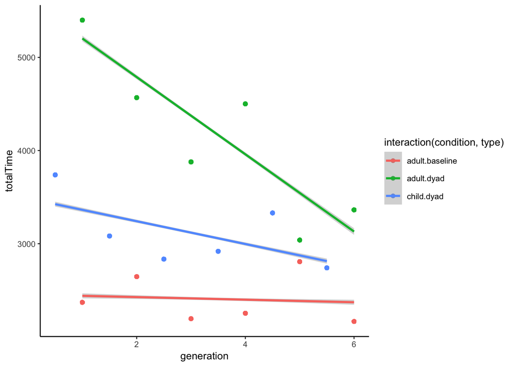

```r
time_used %>%
  group_by(generation, type, condition) %>%
  mutate(totalTime = sum(timeUsed)) %>%
  ggplot(aes(x=generation, y=totalTime, color=interaction(condition,type))) +
  geom_point() +
  geom_smooth(method="lm")
```

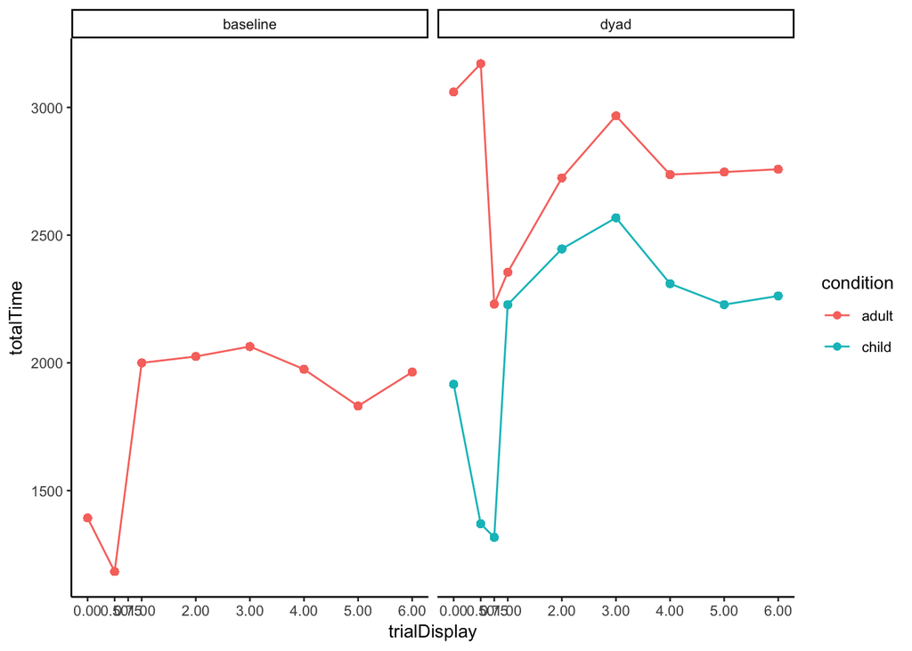

```r
time_used %>%
  group_by(trialDisplay, type, condition) %>%
  mutate(totalTime = sum(timeUsed)) %>%
  ggplot(aes(x=trialDisplay, y=totalTime, color=condition)) +
  geom_point() +
  scale_x_continuous(breaks =c(0, 0.5, 0.75, 1, 2, 3, 4, 5, 6)) +
  facet_wrap(~type) +
  geom_line(aes(group=condition))
```

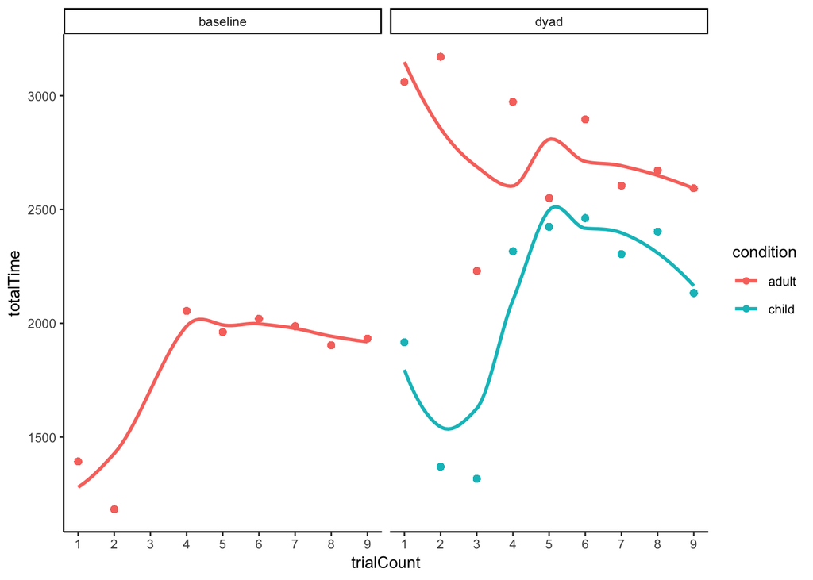

```r
time_used %>%
  group_by(trialCount, type, condition) %>%
  mutate(totalTime = sum(timeUsed)) %>%
  ggplot(aes(x=trialCount, y=totalTime, color=condition)) +
  geom_point() +
  scale_x_continuous(breaks =c(1, 2, 3, 4, 5, 6, 7, 8, 9)) +
  facet_wrap(~type) +
  geom_smooth(method = "loess", se = F, aes(group=condition))
```

## Percent Accuracy

This is one of the methods we can look at to judge the grids that people produced. We expect to see increases in % accuracy across generations because this measure approximates transmission accuracy.

Percent accuracies calculated by %/10 stickers placed correctly between target and input

```r
trial_data <- all_calculate_data %>%
 filter(generation != 0) %>% #takes out initial generations
  filter(target == 1) #calculate out of 10 stickers placed correctly, not 64
```

We don’t see any practice effects within individuals.

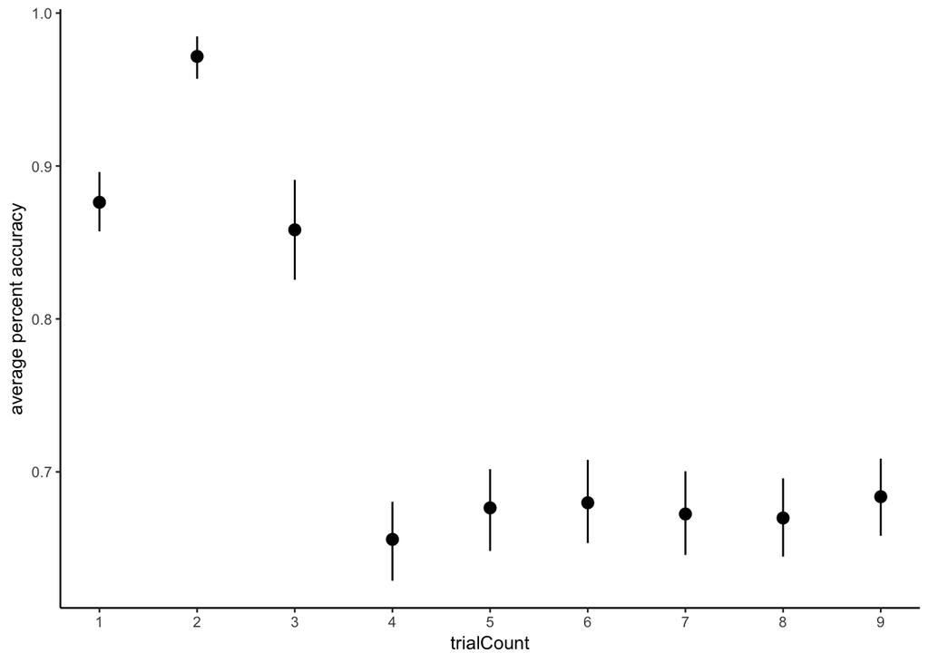

```r
trial_data %>%
  group_by(trialCount, sub_id) %>%
  summarise(accuracy=mean(accuracy)) %>%
  tidyboot_mean(accuracy) %>%
  ggplot(aes(x = trialCount, y = empirical_stat, ymin = ci_lower, ymax = ci_upper)) +
  geom_pointrange()+
  ylab("average percent accuracy") +
  scale_x_continuous(breaks=c(1,2,3,4,5,6,7,8,9))
```

% accuracy by trial display. People found trial 6 to be easier than the other trials overall.

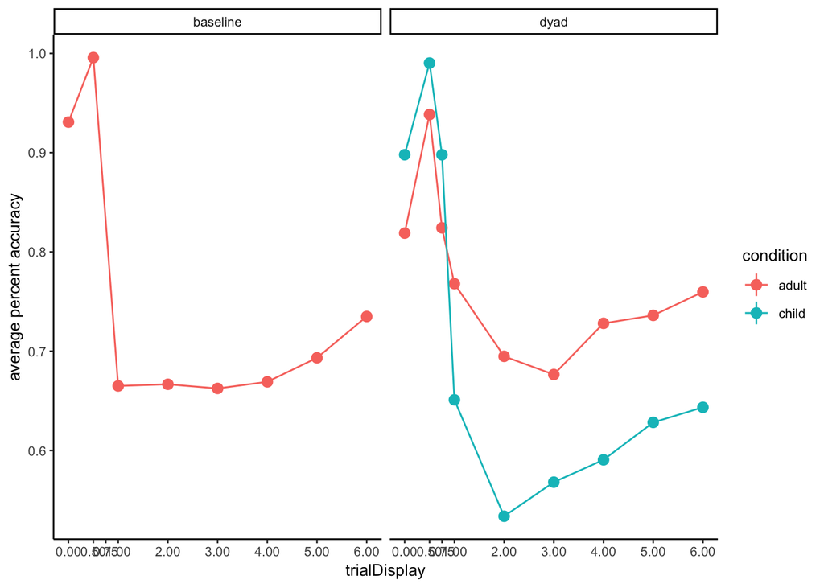

```r
trial_data %>%
  group_by(trialDisplay, type, condition) %>%
  summarise(accuracy=mean(accuracy)) %>%
  group_by(trialDisplay, type, condition) %>%
  tidyboot_mean(accuracy) %>%
  ggplot(aes(x = trialDisplay, y = empirical_stat, ymin = ci_lower, ymax = ci_upper, color=condition)) +
  geom_pointrange()+
  geom_line(aes(group=condition)) +
  ylab("average percent accuracy") +
  scale_x_continuous(breaks=c(0,0.5,0.75,1,2,3,4,5,6)) +
  facet_wrap(~type)
```

Percent accuracy over generations. It increases over gens 1-4 and then seems to level off(?). This is similar to what we would expect but interesting in context with the consistent complexity findings below.

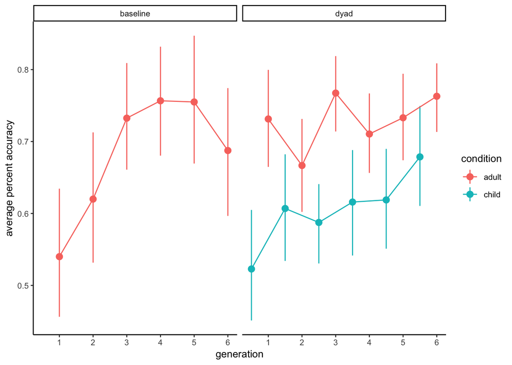

```r
trial_data %>%
  filter(trialCount > 3) %>%
  group_by(generation, sub_id, type, condition) %>%
  summarise(accuracy = mean(accuracy)) %>%
  group_by(generation,type, condition) %>%
  tidyboot_mean(accuracy) %>%
  ggplot(aes(x = generation, y = empirical_stat, ymin = ci_lower, ymax = ci_upper, color = condition)) +
  geom_pointrange()+
  facet_wrap(~type)+
  geom_line(aes(group=condition))+
  ylab("average percent accuracy") +
  scale_x_continuous(breaks=c(0,1,2,3,4,5,6))
```

Percent accuracy over generation by seed to see variations between seeds, though they seem to show similar (ish) trends

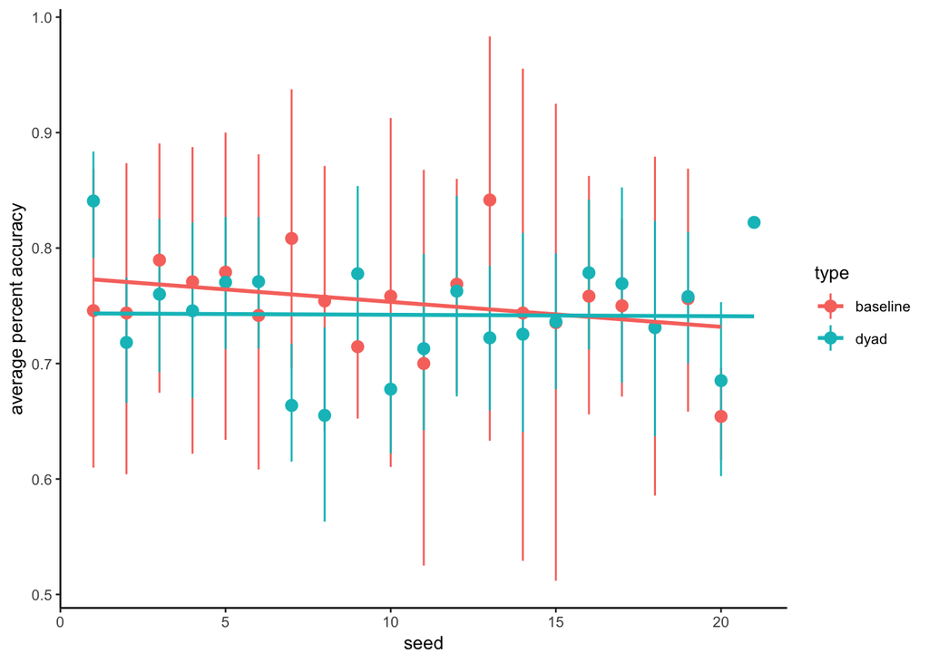

```r
#seeds are diverse but generally constant
trial_data %>%
  group_by(type,seed, sub_id) %>%
  summarise(accuracy=mean(accuracy)) %>%
  tidyboot_mean(accuracy)%>%
  ggplot(aes(x = seed, y = empirical_stat, ymin = ci_lower, ymax = ci_upper, color=type)) +
  geom_pointrange() +
  geom_smooth(method = "lm", se=F)+
  ylab("average percent accuracy")
```

## Analyses of Complexity

There are many different methods of analyzing the “simplicity” or “complexity” of these grids. None of them are perfect, but taken together they present a unfied picture of what is happening over generations.

## BDM

The Block Decomposition Method for Algorithmic Complexity splits the grids into overlapping 4x4 units, and calculates the Kolmogorov-Chaitin Complexity (based on coding theorem method) for each 4x4 grid. This method compares the power used to produce a particular pattern by a turing machine. We have reason to believe that this is the best measure of general complexity that we have for the grids.

## Chunking

Chunking is defined as the number of discrete parts of the grid. A chunk consists of any targets which are connected by an edge. This does not include elements which are diagonal to each other.

## Edge Length

Edge length can be defined as a measure of how “crooked” a grid pattern is. It essentially counts the length of the edges of the targets seen. Targets which are connected have a lower edge length. A checkerboard pattern would result in the largest edge length.

## Results

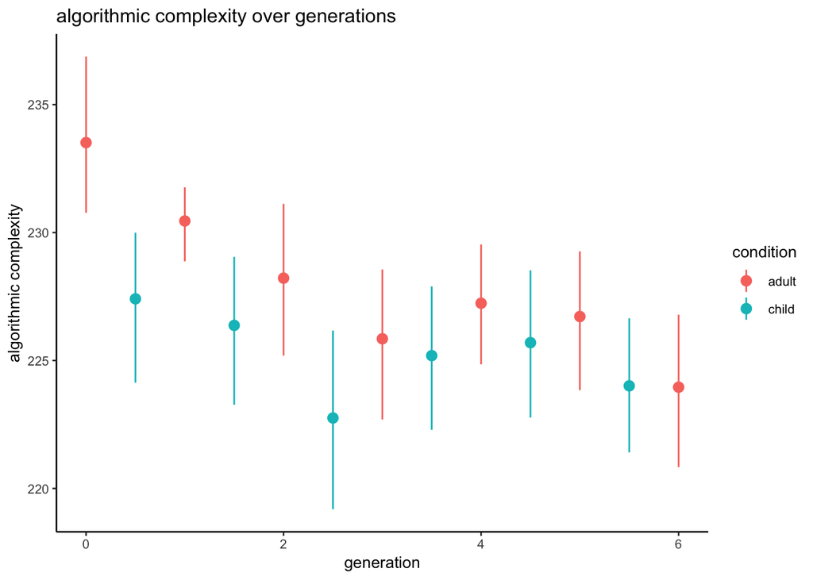

```r
t_bind_data %>%
  mutate(condition = if_else(floor(generation) != generation, "child", "adult")) %>%
  group_by(generation, condition) %>%
  tidyboot_mean(bdm_mean) %>%
  ggplot(aes(x = generation, y = empirical_stat, ymin = ci_lower, ymax = ci_upper, color = condition)) +
  geom_pointrange() +
  ylab("algorithmic complexity") +
  ggtitle("algorithmic complexity over generations")
```

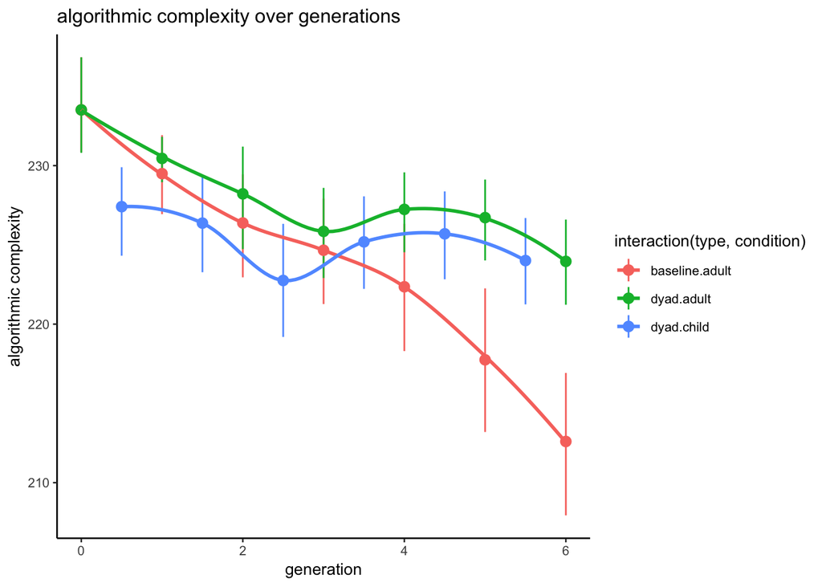

```r
all_bind_data  %>%
  group_by(generation, type) %>%
  tidyboot_mean(bdm_mean) %>%
  mutate(condition = if_else(floor(generation) != generation, "child", "adult")) %>%
  ggplot(aes(x = generation, y = empirical_stat, ymin = ci_lower,
                      ymax = ci_upper, color = interaction(type,condition),                               group=interaction(type,condition))) +
  geom_pointrange() +
  geom_smooth(method = "loess", se = F)+
  ylab("algorithmic complexity") +
  ggtitle("algorithmic complexity over generations")
```

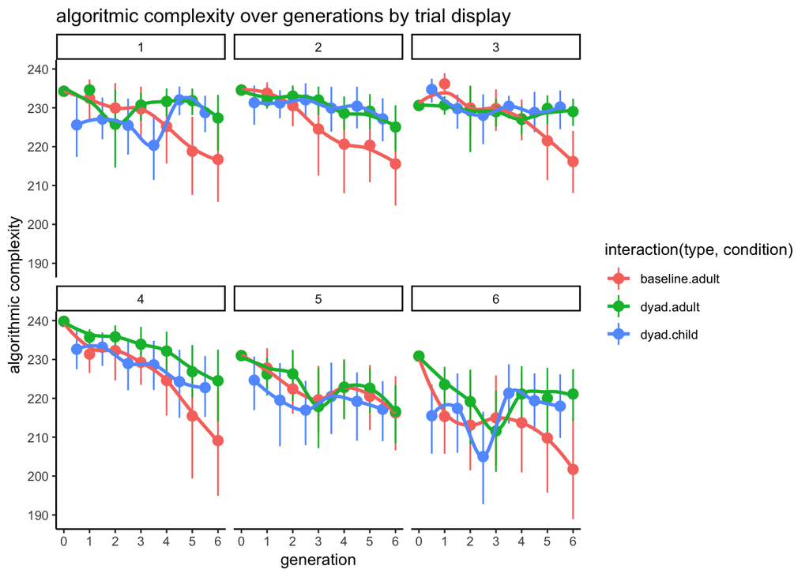

```r
#seems to be variation by trial display
all_bind_data %>%
  group_by(generation, trialDisplay,condition,type) %>%
  tidyboot_mean(bdm_mean) %>%
  ggplot(aes(x = generation, y = empirical_stat,
                       ymin = ci_lower, ymax = ci_upper, color = interaction(type,condition))) +
  geom_pointrange() +
  geom_smooth(method="loess", aes(group=interaction(type, condition)), se=F)+
  ylab("algorithmic complexity") +
  facet_wrap(~trialDisplay) +
  ggtitle("algoritmic complexity over generations by trial display")+
  scale_x_continuous(breaks=c(0,1,2,3,4,5,6))
```

Chunking

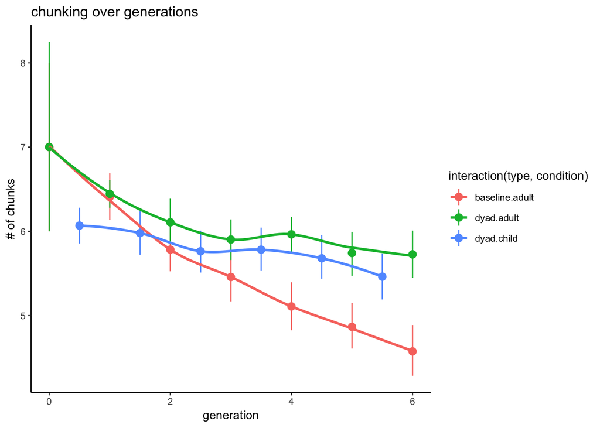

```r
all_bind_data  %>%
  group_by(generation, type) %>%
  tidyboot_mean(chunking_mean) %>%
  mutate(condition = if_else(floor(generation) != generation, "child", "adult")) %>%
  ggplot(aes(x = generation, y = empirical_stat, ymin = ci_lower,
                      ymax = ci_upper, color = interaction(type,condition),                               group=interaction(type,condition))) +
  geom_pointrange() +
  geom_smooth(method = "loess", se = F)+
  ylab("# of chunks") +
  ggtitle("chunking over generations")
```

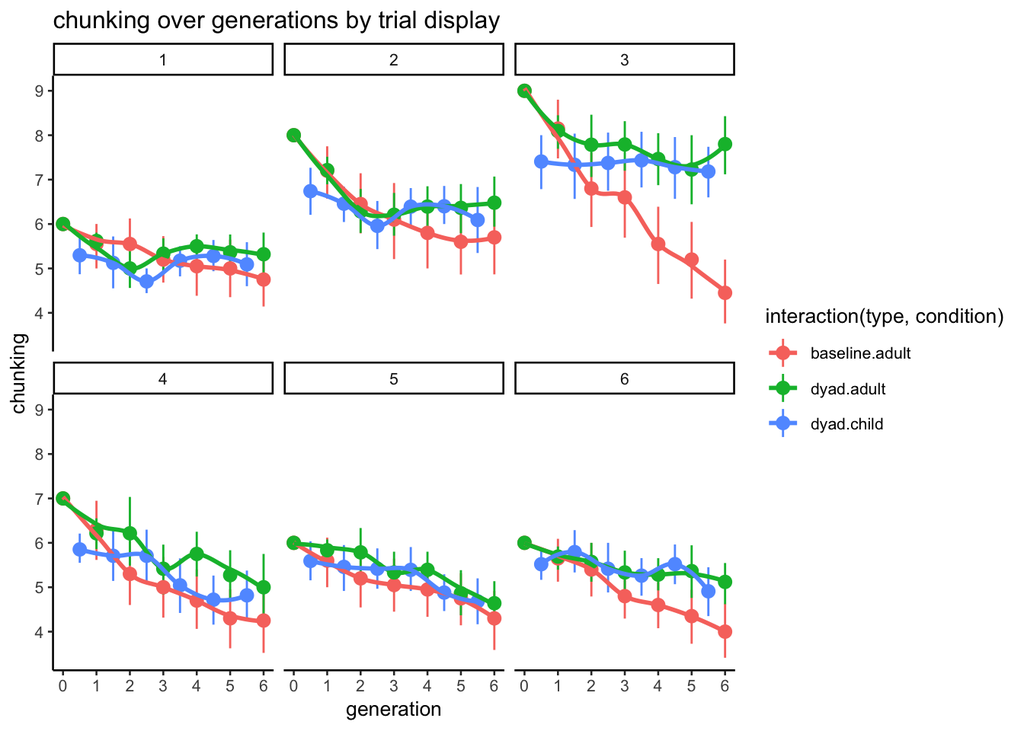

```r
all_bind_data %>%
  group_by(generation, trialDisplay,condition,type) %>%
  tidyboot_mean(chunking_mean) %>%
  ggplot(aes(x = generation, y = empirical_stat,
                       ymin = ci_lower, ymax = ci_upper, color = interaction(type,condition))) +
  geom_pointrange() +
  geom_smooth(method="loess", aes(group=interaction(type, condition)), se=F)+
  ylab("chunking") +
  facet_wrap(~trialDisplay) +
  ggtitle("chunking over generations by trial display")+
  scale_x_continuous(breaks=c(0,1,2,3,4,5,6))
```

Edge Length

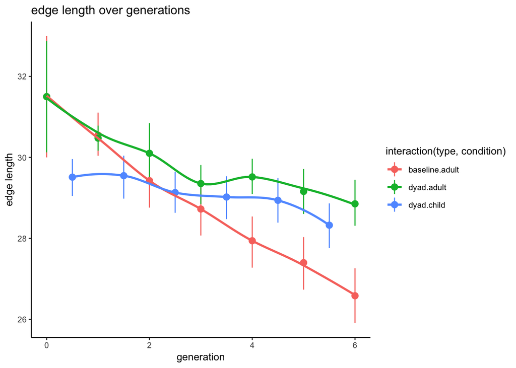

```r
all_bind_data  %>%
  group_by(generation, type) %>%
  tidyboot_mean(edge_mean) %>%
  mutate(condition = if_else(floor(generation) != generation, "child", "adult")) %>%
  ggplot(aes(x = generation, y = empirical_stat, ymin = ci_lower,
                      ymax = ci_upper, color = interaction(type,condition),                               group=interaction(type,condition))) +
  geom_pointrange() +
  geom_smooth(method = "loess", se = F)+
  ylab("edge length") +
  ggtitle("edge length over generations")
```

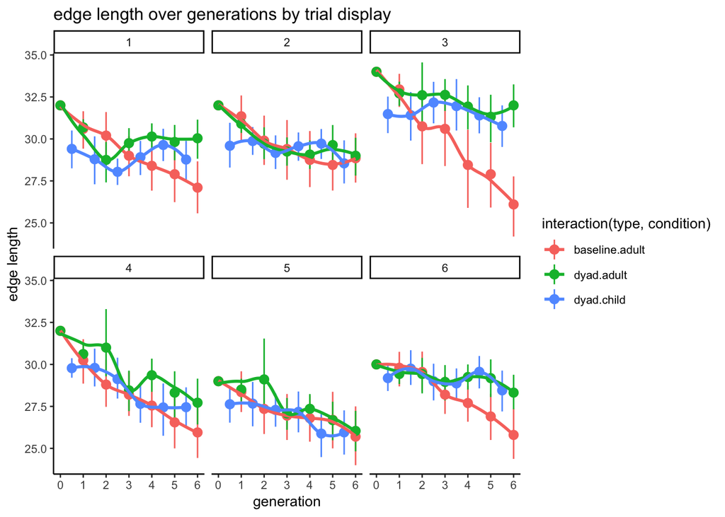

```r
all_bind_data %>%
  group_by(generation, trialDisplay,condition,type) %>%
  tidyboot_mean(edge_mean) %>%
  ggplot(aes(x = generation, y = empirical_stat,
                       ymin = ci_lower, ymax = ci_upper, color = interaction(type,condition))) +
  geom_pointrange() +
  geom_smooth(method="loess", aes(group=interaction(type, condition)), se=F)+
  ylab("edge length") +
  facet_wrap(~trialDisplay) +
  ggtitle("edge length over generations by trial display")+
  scale_x_continuous(breaks=c(0,1,2,3,4,5,6))
```

## Earth-Mover Distance

Earth-Mover Distance is calculated as the number of moves (one move=one direction NSEW) to get from a target pattern to the resultant pattern.

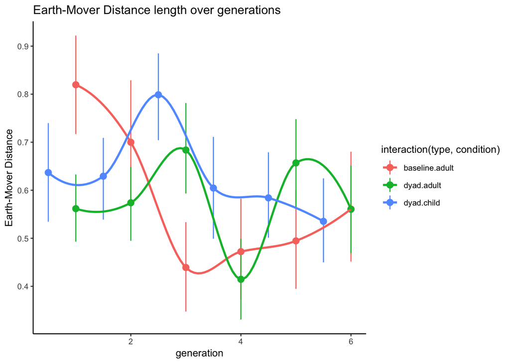

```r
all_bind_data  %>%
  group_by(generation, type) %>%
  filter(generation > 0, trialDisplay != 6) %>%
  tidyboot_mean(emd) %>%
  mutate(condition = if_else(floor(generation) != generation, "child", "adult")) %>%
  ggplot(aes(x = generation, y = empirical_stat, ymin = ci_lower,
                      ymax = ci_upper, color = interaction(type,condition),                               group=interaction(type,condition))) +
  geom_pointrange() +
  geom_smooth(method = "loess", se = F)+
  ylab("Earth-Mover Distance") +
  ggtitle("Earth-Mover Distance length over generations")
```

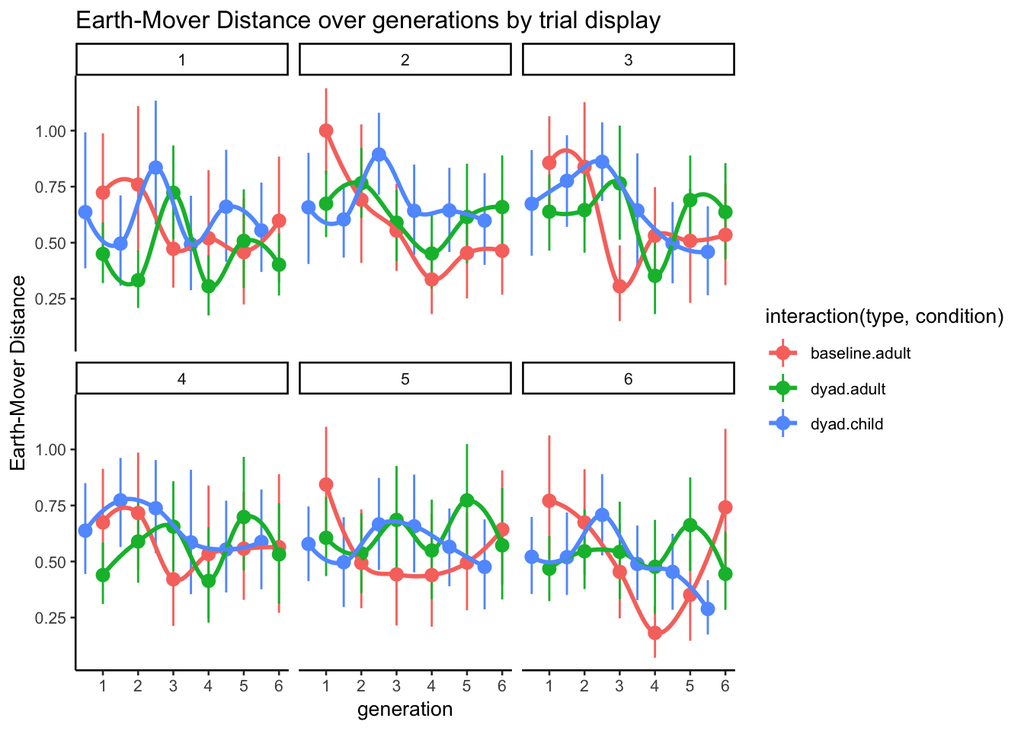

```r
all_bind_data %>%
  filter(generation >0) %>%
  group_by(generation, trialDisplay,condition,type) %>%
  tidyboot_mean(emd) %>%
  ggplot(aes(x = generation, y = empirical_stat,
                       ymin = ci_lower, ymax = ci_upper, color = interaction(type,condition))) +
  geom_pointrange() +
  geom_smooth(method="loess", aes(group=interaction(type, condition)), se=F)+
  ylab("Earth-Mover Distance") +
  facet_wrap(~trialDisplay) +
  ggtitle("Earth-Mover Distance over generations by trial display")+
  scale_x_continuous(breaks=c(0,1,2,3,4,5,6))
```

## Including Seed Information

Inlcuding seed information for complexity, chunking, and edge length yields similar results.

## Identifiability

Kempe et al defined this as the proportion of within-chain similarity / (within-chain)+(across-chain similarity). We will try to define “similarity” two ways: 1) as the percent of same cells highlighted (like we did for % accuracy between target/input, but just with input of gen 1 seed 1 compared to input of gen 1 seed 2) 2) using emd as the measure of similarity (lower emd = more similar, less moves) ^ START WITH THIS MEASURE

## Fixing grids

Want to see how much adults change the input grids they are given. Calculate this by % accuracy from child input to adult input (so you have to edit the data – be wary!)

```r
dyad_data <- turk_dyad %>%
  mutate(target1Array = ifelse(condition =="adult", "1 1 0 0 0 0 0 0 0 0 1 1 0 0 0 0 1 1 0 0 0 0 0 0 0 0 0 0 0 0 0 0 0 0 0 0 0 0 1 1 0 0 0 0 0 0 0 0 0 0 0 0 0 0 1 0 0 0 0 0 0 0 0 1",target1Array),
         target2Array = ifelse(condition =="adult","0 0 0 0 0 0 0 1 0 0 0 0 0 0 1 0 0 0 0 0 0 1 0 0 0 0 0 0 1 0 0 0 0 0 0 1 0 0 0 0 0 0 1 0 0 0 0 0 0 1 0 0 0 0 0 0 1 1 1 0 0 0 0 0",target2Array),
         target3Array = ifelse(condition =="adult", "0 1 0 0 1 0 0 0 0 0 0 0 0 0 0 0 0 0 0 0 0 0 0 0 0 0 0 0 0 0 0 0 0 0 0 0 0 0 0 0 0 0 0 0 0 0 0 0 0 0 0 0 0 0 0 0 1 1 1 1 1 1 1 1",target3Array),
         target4Array = ifelse(condition =="adult", dyad_pilot$data4Array[match(dyad_pilot$parent_id, dyad_pilot$unique_id)],target4Array),
         target5Array = ifelse(condition =="adult", dyad_pilot$data5Array[match(dyad_pilot$parent_id, dyad_pilot$unique_id)],target5Array),
         target6Array = ifelse(condition =="adult", dyad_pilot$data6Array[match(dyad_pilot$parent_id, dyad_pilot$unique_id)],target6Array),
         target7Array = ifelse(condition =="adult", dyad_pilot$data7Array[match(dyad_pilot$parent_id, dyad_pilot$unique_id)],target7Array),
         target8Array = ifelse(condition =="adult", dyad_pilot$data8Array[match(dyad_pilot$parent_id, dyad_pilot$unique_id)],target8Array),
         targetArray = ifelse(condition =="adult", dyad_pilot$data9Array[match(dyad_pilot$parent_id, dyad_pilot$unique_id)],target9Array))
```

```r
dyad <- dyad_data %>%
  select(-(available_onload:available_accepted), -sub_age) %>%
  gather(display, array, -(unique_id:time1Used), -(trial2Count:time2Used),                              -(trial3Count:time3Used),-(trial4Count:time4Used), -(trial5Count:time5Used),                     -(trial6Count:time6Used),-(trial7Count:time7Used), -(trial8Count:time8Used),                     -(trial9Count:time9Used)) %>%
  unique() %>%
  separate(display, c("type", "trialCountArray"), -6) %>%
  separate(trialCountArray, c("trialCount", "arrayCount"), 1) %>%
  gather(trialDisplay, display, -(unique_id:time), -time1Used, -time2Used, -time3Used,-time4Used,       -time5Used, -time6Used, -time7Used, -time8Used, -time9Used,  -type,-trialCount, -array) %>%
  separate(trialDisplay, c("type2", "tmp"), -7) %>%
  separate(type2, c("tmp2", "trialCount2"), -1) %>%
  filter(trialCount2 == trialCount) %>%
  gather(trialTime, timeUsed, -(unique_id:time), -type, -trialCount, -display, -array) %>%
  separate(trialTime, c("tmp", "trialCount3"), -5) %>%
  separate(trialCount3, c("trialCount3", "tmp2"), 1) %>%
  filter(trialCount == trialCount3) %>%
  select(unique_id:time, trialCount, trialDisplay = display, timeUsed, type, array) %>%
  spread(type, array) %>%
  separate(data, input_labs, sep = " ") %>%
  separate(target, target_labs, sep = " ") %>%
  mutate_at(c(input_labs, target_labs, "sub_id", "generation", "seed", "trialCount", "trialDisplay", "timeUsed"), as.numeric) %>%
  mutate(generation = ifelse(condition == "child", generation-0.5, generation))

dyad_calculate_data <-dyad %>%
  gather(row, value,-unique_id:-timeUsed)%>%
  separate(row, c("type","row", "col")) %>%
  spread(type,value) %>%
  mutate(accuracy = input == target, sub_id = as.character(sub_id)) %>%
  arrange(seed, generation)
```

# of changes people made when fixing grids

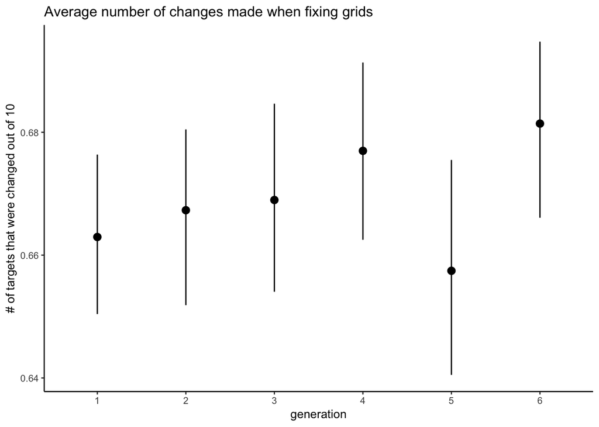

```r
fixed2_data <- dyad_calculate_data %>%
  filter(target ==1) %>%
  filter(condition == "adult") %>%
  group_by(sub_id, trialDisplay) %>%
  mutate(num_changes = sum(ifelse(accuracy ==FALSE, 1, 0)))%>%
  mutate(accuracy=1-mean(accuracy)) %>%
  filter(trialDisplay >=1) %>%
  group_by(generation) %>%
  tidyboot_mean(accuracy) %>%
  mutate(generation = as.factor(generation))

ggplot(fixed2_data, aes(x= generation, y=empirical_stat, ymin=ci_lower, ymax=ci_upper))+
  geom_pointrange()+
  geom_smooth(method="loess")+
  ggtitle("Average number of changes made when fixing grids")+
  ylab("# of targets that were changed out of 10")
```